# Practica2

## EJERCICIO 1. SIMULANDO VARIABLES ALEATORIAS DISCRETAS

Calcula la media y la varianza teóricas de esta variable.

```r
library(viridisLite)
X1 = sample(0:3, size = 10000, replace = TRUE, prob = c(64, 48, 12, 1))

mean(X1)
```

```
## [1] 0.6132
```

```r
sd(X1)
```

```
## [1] 0.6981651
```

### Apartado 2: Combina sample con replicate para simular cien mil muestras de tamaño 10 de esta variable X1.

Estudia la distribución de las medias muestrales como hemos hecho en ejemplos previos, ilustrando con gráficas la distribución de esas medias muestrales. Cambia después el tamaño de la muestra a 30 y repite el análisis.

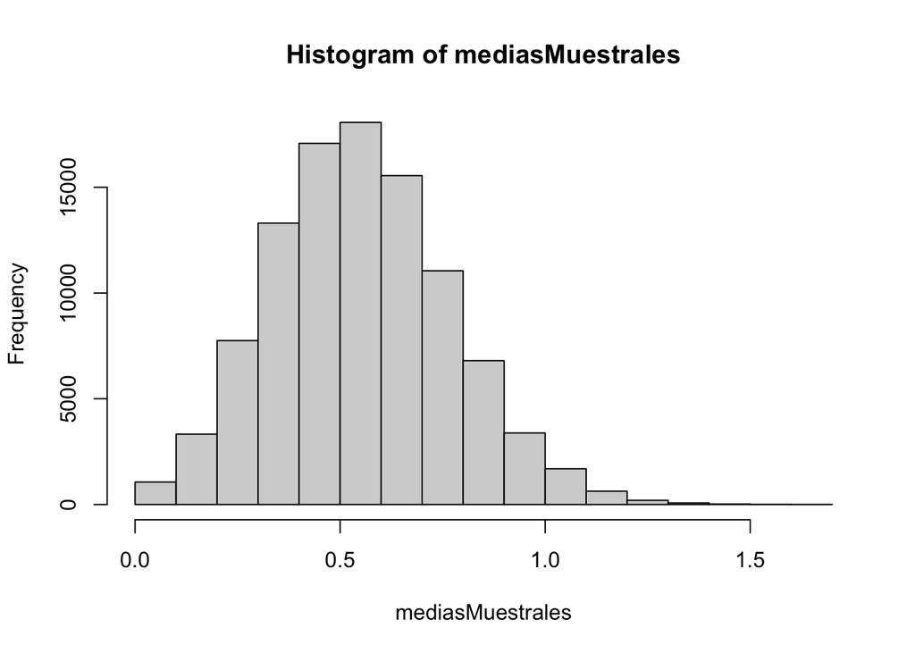

```r
library(ggplot2)
mediasMuestrales = replicate(100000,{
  muestra =sample(0:3, size = 10, replace = TRUE, prob = c(64, 48, 12, 1))
  mean(muestra)

})
hist(mediasMuestrales)
```

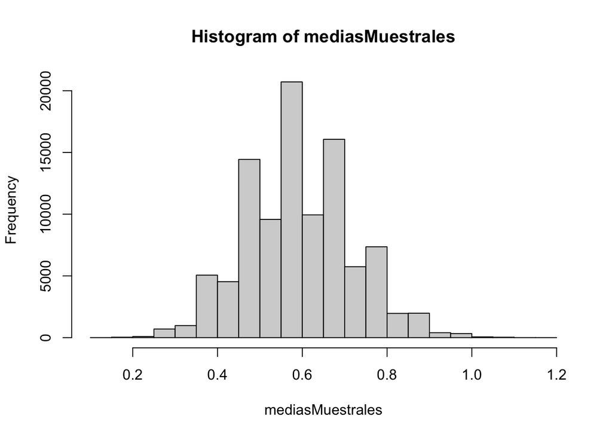

```r
mediasMuestrales = replicate(100000,{
  muestra =sample(0:3, size = 30, replace = TRUE, prob = c(64, 48, 12, 1))
  mean(muestra)

})
hist(mediasMuestrales)
```

### Apartado 3: La variable aleatoria discreta X2 tiene esta tabla de densidad de probabilidad:

```r
X2 = sample(0:2, size = 10000, replace = TRUE, prob = c(0.5, 0.25, 0.25))
```

Suponemos que X1 y X2 son independientes. ¿Qué valores puede tomar la suma X1 + X2? ¿Cuál es su tabla de probabilidad?

Si X1 y X2 son independientes, los valores que pueden tomar son entre 0 y 5

```r
X3<-c(0,1,2,3,4,5)
probSum<-c(0,0,0,0,0,0)
X1 <- c(0,1,2,3)
probX1 <- c(64/125,48/125,12/125,1/125)
probX2 <- c(0.5, 0.25, 0.25)
X2 <-c(0,1,2)
for (num in X1){
  for(num2 in X2){
    probSum[num + num2 +1 ]= probSum[num + num2 +1] + probX2[num2+1]*probX1[num+1]

  }


}


probSum
```

```
## [1] 0.256 0.320 0.272 0.124 0.026 0.002
```

```r
media = sum(probSum*X3)
media
```

```
## [1] 1.35
```

```r
muestra =sample(0:5, size = 10000, replace = TRUE, prob = probSum)
mean(muestra)
```

```
## [1] 1.3511
```

## EJERCICIO 2. DATOS LIMPIOS

Este fichero contiene las notas de los alumnos de una clase, que hicieron dos tests cada semana durante cinco semanas. La tabla de datos no cumple los principios de tidy data que hemos visto en clase. Tu tarea en este ejercicio es explicar por qué no se cumplen y obtener una tabla de datos limpios con la misma información usando tidyR.

```r
library(tidyverse)
file_url <-   "https://gist.githubusercontent.com/fernandosansegundo/471b4887737cfcec7e9cf28631f2e21e/raw/b3944599d02df494f5903740db5acac9da35bc6f/testResults.csv"
# Cambia la siguiente fila si quieres usar una subcarpeta del wd.
local_folder <-  "./"
# No cambies nada a partir de aquí
file_name <- tail(unlist(strsplit(file_url, split = "/")), 1)
localFile <-  paste0(local_folder, file_name)
if(!file.exists(localFile)){
  download.file(url = file_url, destfile = localFile)
} else {
  warning(paste0("Cuidado: el fichero de datos", localFile, " ya existe."))
}
data = read_csv("testResults.csv")
summary(data)
```

```
##      name                 id         gender_age         test_number
##  Length:200         Min.   :101.0   Length:200         Min.   :1.0
##  Class :character   1st Qu.:291.5   Class :character   1st Qu.:1.0
##  Mode  :character   Median :488.0   Mode  :character   Median :1.5
##                     Mean   :520.6                      Mean   :1.5
##                     3rd Qu.:760.0                      3rd Qu.:2.0
##                     Max.   :981.0                      Max.   :2.0
##      week1          week2           week3           week4
##  Min.   : 0.0   Min.   : 0.00   Min.   : 0.00   Min.   : 0.00
##  1st Qu.: 2.0   1st Qu.: 2.00   1st Qu.: 2.00   1st Qu.: 2.00
##  Median : 5.0   Median : 5.00   Median : 5.00   Median : 5.00
##  Mean   : 4.9   Mean   : 4.89   Mean   : 4.84   Mean   : 5.08
##  3rd Qu.: 8.0   3rd Qu.: 8.00   3rd Qu.: 7.00   3rd Qu.: 8.00
##  Max.   :10.0   Max.   :10.00   Max.   :10.00   Max.   :10.00
##      week5
##  Min.   : 0.000
##  1st Qu.: 2.000
##  Median : 5.000
##  Mean   : 4.875
##  3rd Qu.: 7.000
##  Max.   :10.000
```

```r
data[1,]
```

```
## # A tibble: 1 × 9
##   name     id gender_age test_number week1 week2 week3 week4 week5
##   <chr> <dbl> <chr>            <dbl> <dbl> <dbl> <dbl> <dbl> <dbl>
## 1 Jacob   108 m_20                 1     8     5     7     5     6
```

Al observar un registro se comprueba como la tabla contiene una columna con dos variables, el genero y la edad. Para que la tabla pueda analizarse de manera adecuada es necesario la división de estas dos variables.

```r
newData<- data %>%
  separate(gender_age, into=c('gender','age'),sep='_', convert=TRUE)

newData
```

```
## # A tibble: 200 × 10
##    name           id gender   age test_number week1 week2 week3 week4 week5
##    <chr>       <dbl> <chr>  <int>       <dbl> <dbl> <dbl> <dbl> <dbl> <dbl>
##  1 Jacob         108 m         20           1     8     5     7     5     6
##  2 Jacob         108 m         20           2     2     2     4     0     3
##  3 Michael       490 m         19           1    10     0     5     4     0
##  4 Michael       490 m         19           2     9    10     8    10     9
##  5 Matthew       424 m         18           1     6     0     0     1    10
##  6 Matthew       424 m         18           2     3     4     2     5     8
##  7 Joshua        734 m         17           1    10     2     2     0     6
##  8 Joshua        734 m         17           2    10     0     6     8     9
##  9 Christopher   928 m         20           1     5     2     0     0     0
## 10 Christopher   928 m         20           2     9     9     3    10     4
## # … with 190 more rows
```

## EJERCICIO 3. LECTURA DE R4DS

Haz el ejercicio 2 de la Sección 7.5.1.1 de R4DS. Las ideas de esa sección son importantes para nuestro trabajo de las próximas sesiones.

### 2. ¿Qué variable del conjunto de datos de diamantes es más importante para predecir el precio de un diamante? ¿Cómo está correlacionada esta variable con el corte? ¿Por qué la combinación de estas dos relaciones conlleva que los diamantes de menor calidad sean más costosos?

```r
library(datos)
?diamantes
cor(x=diamantes$precio,y=diamantes$quilate)
```

```
## [1] 0.9215913
```

```r
cor(x=diamantes$precio,y=diamantes$profundidad)
```

```
## [1] -0.0106474
```

```r
cor(x=diamantes$precio,y=diamantes$tabla)
```

```
## [1] 0.1271339
```

```r
cor(x=diamantes$precio,y=diamantes$x)
```

```
## [1] 0.8844352
```

```r
cor(x=diamantes$precio,y=diamantes$y)
```

```
## [1] 0.8654209
```

```r
cor(x=diamantes$precio,y=diamantes$z)
```

```
## [1] 0.8612494
```

Tal y como se puede comprobar la correlación con el precio es mayor con el quilate, con lo cual la variable más explicativa para predecir el precio del diamante es el quilate

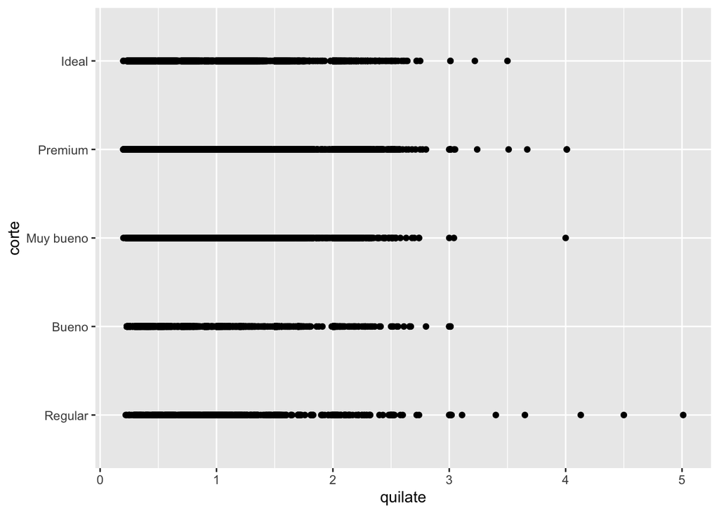

```r
ggplot(data=diamantes) +
  geom_point(mapping=aes(x=quilate, y=corte))
```

Haz el ejercicio 4 de la Sección 12.6.1 de R4DS. ¡Aprovecha el código previo de esa sección para trabajar con datos limpios!

### 4. Para cada país, año y sexo calcula el total del número de casos de tuberculosis. Crea una visualización informativa de los datos

```r
oms
```

```
## # A tibble: 7,240 × 60
##    pais       iso2  iso3   anio nuevos_fpp_h014 nuevos_fpp_h1524 nuevos_fpp_h2534
##    <chr>      <chr> <chr> <int>           <int>            <int>            <int>
##  1 Afganistán AF    AFG    1980              NA               NA               NA
##  2 Afganistán AF    AFG    1981              NA               NA               NA
##  3 Afganistán AF    AFG    1982              NA               NA               NA
##  4 Afganistán AF    AFG    1983              NA               NA               NA
##  5 Afganistán AF    AFG    1984              NA               NA               NA
##  6 Afganistán AF    AFG    1985              NA               NA               NA
##  7 Afganistán AF    AFG    1986              NA               NA               NA
##  8 Afganistán AF    AFG    1987              NA               NA               NA
##  9 Afganistán AF    AFG    1988              NA               NA               NA
## 10 Afganistán AF    AFG    1989              NA               NA               NA
## # … with 7,230 more rows, and 53 more variables: nuevos_fpp_h3534 <int>,
## #   nuevos_fpp_h4554 <int>, nuevos_fpp_h5564 <int>, nuevos_fpp_h65 <int>,
## #   nuevos_fpp_m014 <int>, nuevos_fpp_m1524 <int>, nuevos_fpp_m2534 <int>,
## #   nuevos_fpp_m3534 <int>, nuevos_fpp_m4554 <int>, nuevos_fpp_m5564 <int>,
## #   nuevos_fpp_m65 <int>, nuevos_fpn_h014 <int>, nuevos_fpn_h1524 <int>,
## #   nuevos_fpn_h2534 <int>, nuevos_fpn_h3534 <int>, nuevos_fpn_h4554 <int>,
## #   nuevos_fpn_h5564 <int>, nuevos_fpn_h65 <int>, nuevos_fpn_m014 <int>, …
```

```r
oms1 <- oms %>%
  pivot_longer(
    cols=nuevos_fpp_h014:nuevosrecaida_m65,
    names_to="clave",
    values_to="casos",
    values_drop_na = TRUE
  )
oms1
```

```
## # A tibble: 76,046 × 6
##    pais       iso2  iso3   anio clave            casos
##    <chr>      <chr> <chr> <int> <chr>            <int>
##  1 Afganistán AF    AFG    1997 nuevos_fpp_h014      0
##  2 Afganistán AF    AFG    1997 nuevos_fpp_h1524    10
##  3 Afganistán AF    AFG    1997 nuevos_fpp_h2534     6
##  4 Afganistán AF    AFG    1997 nuevos_fpp_h3534     3
##  5 Afganistán AF    AFG    1997 nuevos_fpp_h4554     5
##  6 Afganistán AF    AFG    1997 nuevos_fpp_h5564     2
##  7 Afganistán AF    AFG    1997 nuevos_fpp_h65       0
##  8 Afganistán AF    AFG    1997 nuevos_fpp_m014      5
##  9 Afganistán AF    AFG    1997 nuevos_fpp_m1524    38
## 10 Afganistán AF    AFG    1997 nuevos_fpp_m2534    36
## # … with 76,036 more rows
```

```r
oms2 <- oms1 %>%
  mutate(clave=stringr::str_replace(clave,"nuevosrecaida", "nuevos_recaida"))
oms2
```

```
## # A tibble: 76,046 × 6
##    pais       iso2  iso3   anio clave            casos
##    <chr>      <chr> <chr> <int> <chr>            <int>
##  1 Afganistán AF    AFG    1997 nuevos_fpp_h014      0
##  2 Afganistán AF    AFG    1997 nuevos_fpp_h1524    10
##  3 Afganistán AF    AFG    1997 nuevos_fpp_h2534     6
##  4 Afganistán AF    AFG    1997 nuevos_fpp_h3534     3
##  5 Afganistán AF    AFG    1997 nuevos_fpp_h4554     5
##  6 Afganistán AF    AFG    1997 nuevos_fpp_h5564     2
##  7 Afganistán AF    AFG    1997 nuevos_fpp_h65       0
##  8 Afganistán AF    AFG    1997 nuevos_fpp_m014      5
##  9 Afganistán AF    AFG    1997 nuevos_fpp_m1524    38
## 10 Afganistán AF    AFG    1997 nuevos_fpp_m2534    36
## # … with 76,036 more rows
```

```r
oms3 <- oms2 %>%
  separate(clave, c("nuevos", "tipo", "sexo_edad"), sep = "_")

oms4 <- oms3 %>%
  select(-nuevos,-iso2,-iso3)


oms5 <- oms4 %>%
  separate(sexo_edad, c("sexo", "edad"), sep = 1)
oms5
```

```
## # A tibble: 76,046 × 6
##    pais        anio tipo  sexo  edad  casos
##    <chr>      <int> <chr> <chr> <chr> <int>
##  1 Afganistán  1997 fpp   h     014       0
##  2 Afganistán  1997 fpp   h     1524     10
##  3 Afganistán  1997 fpp   h     2534      6
##  4 Afganistán  1997 fpp   h     3534      3
##  5 Afganistán  1997 fpp   h     4554      5
##  6 Afganistán  1997 fpp   h     5564      2
##  7 Afganistán  1997 fpp   h     65        0
##  8 Afganistán  1997 fpp   m     014       5
##  9 Afganistán  1997 fpp   m     1524     38
## 10 Afganistán  1997 fpp   m     2534     36
## # … with 76,036 more rows
```

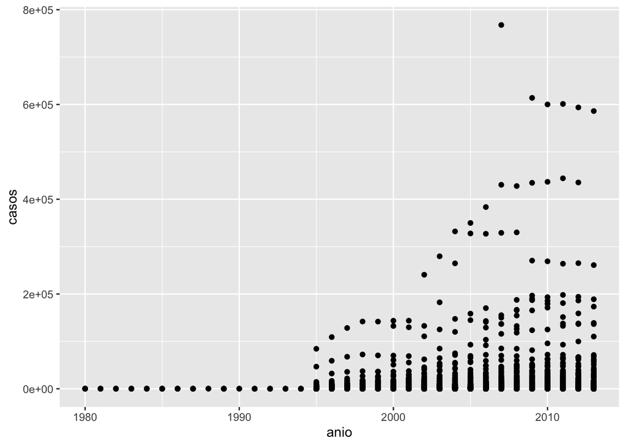

```r
oms5 %>%
  group_by(pais,anio,sexo) %>%
  summarise(casos=sum(casos)) %>%
ggplot(aes(x=anio,y=casos),colour=sexo) +
  geom_point()
```